# Experiment #1.1 - Calibrated Models

## Overview

The purpose of this experiment is to extend our baseline ML models, and compare their results with the baseline.

```python
%load_ext autoreload
%autoreload 2

from utils import code
from plot_libraries import setup_graphics
from datasets import get_data
```

```python
#Main Libraries
import os, random, re, sys, warnings
import numpy as np
import pandas as pd
import matplotlib.pyplot as plt
import seaborn as sns

#Data transform (pipeline)
from sklearn.preprocessing import OneHotEncoder, FunctionTransformer
from sklearn.preprocessing import MinMaxScaler,RobustScaler
from sklearn.compose import ColumnTransformer
from sklearn.pipeline import Pipeline, FeatureUnion
from sklearn.impute import SimpleImputer


# Model evaluation
import scikitplot as skplt
from sklearn.metrics import make_scorer, roc_auc_score, brier_score_loss, classification_report, confusion_matrix, log_loss
from sklearn.model_selection import train_test_split, cross_val_predict
from evaluation import plot_learning_curve, evaluate_model, plot_confusion_matrix, plot_feature_permutation, plot_calibration_curve, get_cv_scores

# Support
import parameters as params
from model import Model, build_tuned_model
from datasets import get_data
from experiments import experiment_1, get_scorer


#setup
warnings.filterwarnings("ignore")
pd.options.display.max_columns = None
sns.set()
%matplotlib inline
setup_graphics()
```

## Data

```python
X, y = get_data('../data/trainDF.csv')
X_train, X_test, y_train, y_test = train_test_split(X, y, test_size=.2, stratify=y, random_state=20)
```

### Calibrated ML models

We will evaluate some hiperparameters such as **class_weghts** (when it is available), and **CalibratedClassifierCV** techniques.

##### Setup Experiment

We will set up the same pipeline, but on second stage we will calibrate the model

```
CalibratedClassifierCV(base_estimator=model.model, cv="prefit", method='isotonic')
```

```python
pipeline1 = experiment_1.get_full_pipeline()
```

```python
scorer = make_scorer(roc_auc_score)
results, res_cv, res_calibrated, n_iter = list(), dict(), dict(), 100
```

**Logistic Regression**

Exp 1.0 - best lr score (AUC): `0.653`

```
==> Starting 5-fold cross validation for lr model, 1479 examples
==> Elapsed seconds: 25.612
Best lr model: LogisticRegression(C=100.0, class_weight='balanced', dual=False,
                   fit_intercept=True, intercept_scaling=1, l1_ratio=None,
                   max_iter=100, multi_class='auto', n_jobs=None, penalty='l2',
                   random_state=None, solver='liblinear', tol=0.0001, verbose=0,
                   warm_start=False)
Best lr score: 0.738

======== lr:
>Brier Score: 0.139
>ROC AUC: 0.856
>Precision class 1: 0.534
              precision    recall  f1-score   support

           0       0.94      0.87      0.90       307
           1       0.53      0.75      0.62        63

    accuracy                           0.85       370
   macro avg       0.74      0.81      0.76       370
weighted avg       0.87      0.85      0.86       370

Confusion matrix:
[[266  41]
 [ 16  47]]


======== lr + Isotonic:
>Brier Score: 0.096
>ROC AUC: 0.852
>Precision class 1: 0.686
              precision    recall  f1-score   support

           0       0.88      0.96      0.92       307
           1       0.69      0.38      0.49        63

    accuracy                           0.86       370
   macro avg       0.78      0.67      0.71       370
weighted avg       0.85      0.86      0.85       370

Confusion matrix:
[[296  11]
 [ 39  24]]
```

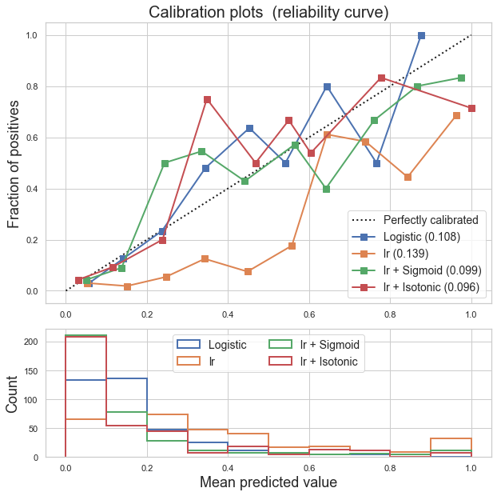

```python
from sklearn.linear_model import LogisticRegression
lr_param_grid = {
  'lr__C': np.logspace(-3, 2, 6),
  'lr__intercept_scaling': [1],
  'lr__max_iter': [100],
  'lr__penalty':  ['l1', 'l2'],
  'lr__solver': ['liblinear'], #good for small datasets
  'lr__tol': [0.0001],
  'lr__class_weight': [None, {0:1,1:1}, {0:1,1:10}, {0:1,1:100}, 'balanced']

}

#0.658=>0.738 (AUC)
result = evaluate_model(X_train, y_train, 'lr',
                        LogisticRegression(),
                        lr_param_grid,
                        scorer, n_iter=n_iter,
                        cv_folds=5, pipeline=pipeline1)
results.append(result)
res_cv[result[1]] = get_cv_scores(result[0])
res_calibrated[result[1]] = plot_calibration_curve(result[0], X_train, X_test, y_train, y_test, False)
```

**SGD Classifier**

Exp 1.0 - best sgd score (AUC): `0.678`

```
==> Starting 5-fold cross validation for sgd model, 1479 examples
==> Elapsed seconds: 16.295
Best sgd model: SGDClassifier(alpha=0.001, average=False, class_weight={0: 1, 1: 10},
              early_stopping=False, epsilon=0.1, eta0=0.0, fit_intercept=True,
              l1_ratio=0.15, learning_rate='optimal', loss='log', max_iter=1000,
              n_iter_no_change=5, n_jobs=-1, penalty='l1', power_t=0.5,
              random_state=None, shuffle=True, tol=0.001,
              validation_fraction=0.1, verbose=0, warm_start=False)
Best sgd score: 0.760

======== sgd:
>Brier Score: 0.167
>ROC AUC: 0.862
>Precision class 1: 0.430
              precision    recall  f1-score   support

           0       0.96      0.78      0.86       307
           1       0.43      0.83      0.57        63

    accuracy                           0.78       370
   macro avg       0.69      0.80      0.71       370
weighted avg       0.87      0.78      0.81       370

Confusion matrix:
[[238  69]
 [ 11  52]]


======== sgd + Isotonic:
>Brier Score: 0.094
>ROC AUC: 0.864
>Precision class 1: 0.759
              precision    recall  f1-score   support

           0       0.88      0.98      0.93       307
           1       0.76      0.35      0.48        63

    accuracy                           0.87       370
   macro avg       0.82      0.66      0.70       370
weighted avg       0.86      0.87      0.85       370

Confusion matrix:
[[300   7]
 [ 41  22]]
```

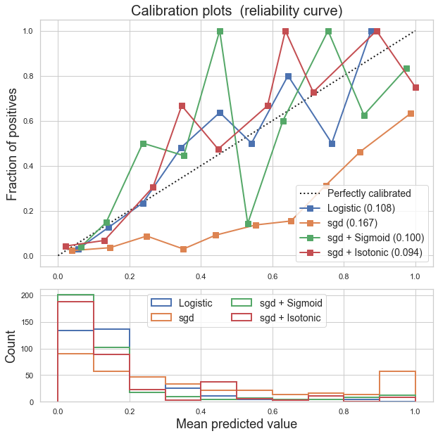

```python
from sklearn.linear_model import SGDClassifier
sgd_param_grid = {
  'sgd__alpha' : np.logspace(-4, 3, 8),
  'sgd__loss' : ['log'], #['log','hinge'],
  'sgd__max_iter' : [1000],
  'sgd__n_jobs' : [-1],
  'sgd__penalty' : ['l2', 'l1', 'elasticnet'],
  'sgd__tol' : [0.001],
  'sgd__class_weight': [None, {0:1,1:1}, {0:1,1:10}, {0:1,1:100}, 'balanced']
}

#0.694=>0.747
result = evaluate_model(X_train, y_train, 'sgd',
                        SGDClassifier(),
                        sgd_param_grid,
                        scorer, n_iter=n_iter,
                        cv_folds=5, pipeline=pipeline1)
results.append(result)
res_cv[result[1]] = get_cv_scores(result[0])
res_calibrated[result[1]] = plot_calibration_curve(result[0], X_train, X_test, y_train, y_test, False)
```

**XGBoost**

Exp 1.0 - best sgd score (AUC): `0.753`

```
==> Starting 5-fold cross validation for xgb model, 1479 examples
==> Elapsed seconds: 133.794
Best xgb model: XGBClassifier(base_score=0.5, booster=None, colsample_bylevel=0.7,
              colsample_bynode=1, colsample_bytree=0.7, gamma=0.24, gpu_id=-1,
              importance_type='gain', interaction_constraints=None,
              learning_rate=0.3, max_delta_step=0, max_depth=9,
              min_child_weight=9, missing=nan, monotone_constraints=None,
              n_estimators=250, n_jobs=0, num_parallel_tree=1,
              objective='binary:logistic', random_state=0,
              reg_alpha=0.21544346900318834, reg_lambda=0.5994842503189408,
              scale_pos_weight=1000, subsample=1.0, tree_method=None,
              validate_parameters=False, verbosity=None)
Best xgb score: 0.831

======== xgb:
>Brier Score: 0.106
>ROC AUC: 0.908
>Precision class 1: 0.585
              precision    recall  f1-score   support

           0       0.95      0.89      0.92       307
           1       0.59      0.76      0.66        63

    accuracy                           0.87       370
   macro avg       0.77      0.83      0.79       370
weighted avg       0.89      0.87      0.87       370

Confusion matrix:
[[273  34]
 [ 15  48]]


======== xgb + Isotonic:
>Brier Score: 0.095
>ROC AUC: 0.826
>Precision class 1: 0.720
              precision    recall  f1-score   support

           0       0.92      0.95      0.93       307
           1       0.72      0.57      0.64        63

    accuracy                           0.89       370
   macro avg       0.82      0.76      0.79       370
weighted avg       0.88      0.89      0.88       370

Confusion matrix:
[[293  14]
 [ 27  36]]
```

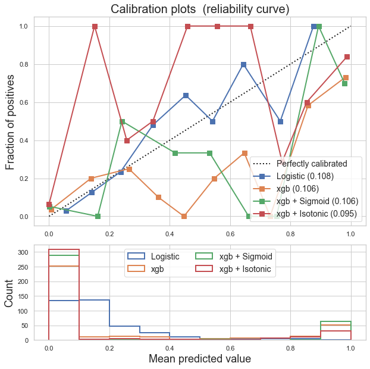

```python
from xgboost import XGBClassifier
xgb_param_grid = {
        'xgb__colsample_bylevel' : [0.1, 0.2, 0.3, 0.4, 0.5, 0.6, 0.7, 0.8, 1.0],
        'xgb__colsample_bytree' :[0.6, 0.7, 0.8, 1.0],
        'xgb__gamma' : list(np.linspace(0.05, 1, 6)),
        'xgb__learning_rate' : [0.0001, 0.001, 0.01, 0.1, 0.2, 0.3],
        'xgb__max_depth' : list(range(3, 30, 3)),
        'xgb__min_child_weight' : list(range(1, 11, 2)),
        'xgb__n_estimators' : list(range(50, 400, 50)),
        'xgb__reg_alpha' : list(np.logspace(-1, 1, num=10)/10),
        'xgb__reg_lambda' : list(np.logspace(-1, 1, num=10)/10),
        'xgb__subsample' : [0.6, 0.7, 0.8, 1.0],
        'xgb__scale_pos_weight' : [1, 10, 25, 50, 75, 99, 100, 1000, 3000,5000, 10000]


}

#0.829
result = evaluate_model(X_train, y_train, 'xgb',
                        XGBClassifier(),
                        xgb_param_grid,
                        scorer, n_iter=n_iter,
                        cv_folds=5, pipeline=pipeline1)
results.append(result)
res_cv[result[1]] = get_cv_scores(result[0])
res_calibrated[result[1]] = plot_calibration_curve(result[0], X_train, X_test, y_train, y_test, False)
```

**Light GBM**

Exp 1.0 - best sgd score (AUC): `0.808`

```
==> Starting 5-fold cross validation for lgbm model, 1479 examples
==> Elapsed seconds: 30.918
Best lgbm model: LGBMClassifier(boosting_type='dart', class_weight={0: 1, 1: 10},
               colsample_bytree=1.0, importance_type='split',
               is_unbalance=False, learning_rate=0.29156525567631103,
               max_depth=-1, min_child_samples=110, min_child_weight=0.001,
               min_split_gain=0.0, n_estimators=100, n_jobs=-1, num_leaves=33,
               objective=None, random_state=None,
               reg_alpha=0.061224489795918366, reg_lambda=0.1020408163265306,
               silent=True, subsample=0.5606060606060606,
               subsample_for_bin=280000, subsample_freq=0)
Best lgbm score: 0.813

======== lgbm:
>Brier Score: 0.116
>ROC AUC: 0.897
>Precision class 1: 0.520
              precision    recall  f1-score   support

           0       0.96      0.85      0.90       307
           1       0.52      0.81      0.63        63

    accuracy                           0.84       370
   macro avg       0.74      0.83      0.77       370
weighted avg       0.88      0.84      0.85       370

Confusion matrix:
[[260  47]
 [ 12  51]]


======== lgbm + Isotonic:
>Brier Score: 0.096
>ROC AUC: 0.810
>Precision class 1: 0.723
              precision    recall  f1-score   support

           0       0.91      0.96      0.93       307
           1       0.72      0.54      0.62        63

    accuracy                           0.89       370
   macro avg       0.82      0.75      0.78       370
weighted avg       0.88      0.89      0.88       370

Confusion matrix:
[[294  13]
 [ 29  34]]
```

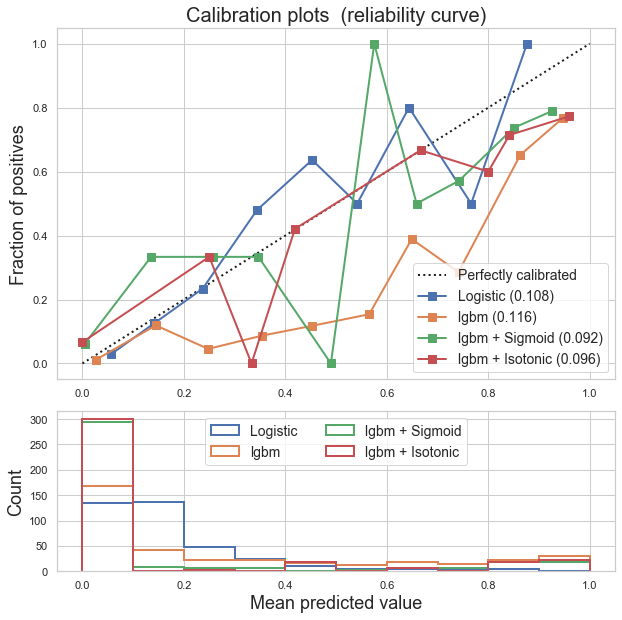

```python
from lightgbm import LGBMClassifier
lgbm_param_grid = {
    'lgbm__boosting_type': ['gbdt', 'goss', 'dart'],
    'lgbm__num_leaves': list(range(20, 150)),
    'lgbm__learning_rate': list(np.logspace(np.log10(0.005), np.log10(0.5), base = 10, num = 1000)),
    'lgbm__subsample_for_bin': list(range(20000, 300000, 20000)),
    'lgbm__min_child_samples': list(range(20, 500, 5)),
    'lgbm__reg_alpha': list(np.linspace(0, 1)),
    'lgbm__reg_lambda': list(np.linspace(0, 1)),
    'lgbm__colsample_bytree': list(np.linspace(0.6, 1, 10)),
    'lgbm__subsample': list(np.linspace(0.5, 1, 100)),
    'lgbm__is_unbalance': [True, False],
    'lgbm__class_weight': [None, {0:1,1:1}, {0:1,1:10}, {0:1,1:100}, 'balanced']

}


#0.811=>0.822
result = evaluate_model(X_train, y_train, 'lgbm',
                        LGBMClassifier(),
                        lgbm_param_grid,
                        scorer, n_iter=n_iter,
                        cv_folds=5, pipeline=pipeline1)
results.append(result)
res_cv[result[1]] = get_cv_scores(result[0])
res_calibrated[result[1]] = plot_calibration_curve(result[0], X_train, X_test, y_train, y_test, False)
```

**K-Nearest Neighboors**

Exp 1.0 - best sgd score (AUC): `0.566`

```
==> Starting 5-fold cross validation for knn model, 1479 examples
==> Elapsed seconds: 76.394
Best knn model: KNeighborsClassifier(algorithm='auto', leaf_size=20, metric='euclidean',
                     metric_params=None, n_jobs=None, n_neighbors=2, p=2,
                     weights='distance')
Best knn score: 0.566

======== knn:
>Brier Score: 0.197
>ROC AUC: 0.548
>Precision class 1: 0.211
              precision    recall  f1-score   support

           0       0.84      0.85      0.85       307
           1       0.21      0.19      0.20        63

    accuracy                           0.74       370
   macro avg       0.52      0.52      0.52       370
weighted avg       0.73      0.74      0.74       370

Confusion matrix:
[[262  45]
 [ 51  12]]


======== knn + Isotonic:
>Brier Score: 0.197
>ROC AUC: 0.548
>Precision class 1: 0.211
              precision    recall  f1-score   support

           0       0.84      0.85      0.85       307
           1       0.21      0.19      0.20        63

    accuracy                           0.74       370
   macro avg       0.52      0.52      0.52       370
weighted avg       0.73      0.74      0.74       370

Confusion matrix:
[[262  45]
 [ 51  12]]
```

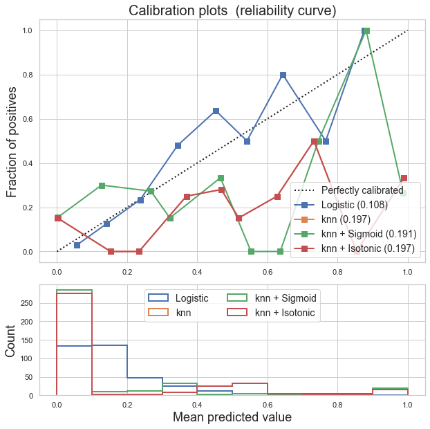

```python
from sklearn.neighbors import KNeighborsClassifier
knn_param_grid =  {
  'knn__leaf_size' : list(range(2, 40, 2)),
  'knn__metric' : ['euclidean', 'manhattan'],
  'knn__n_neighbors' : list(range(2, 18, 2)),
  'knn__p' : [2,3],
  'knn__weights' : ['uniform', 'distance']
}

#0.566
result = evaluate_model(X_train, y_train, 'knn',
                        KNeighborsClassifier(),
                        knn_param_grid,
                        scorer, n_iter=n_iter,
                        cv_folds=5, pipeline=pipeline1)
results.append(result)
res_cv[result[1]] = get_cv_scores(result[0])
res_calibrated[result[1]] = plot_calibration_curve(result[0], X_train, X_test, y_train, y_test, False)
```

### Comparing results

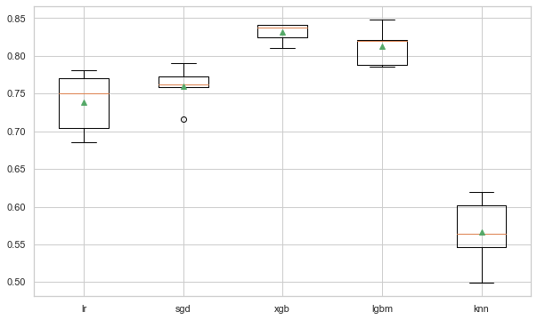

```python
_ = plt.boxplot(res_cv.values(), labels=res_cv.keys(), showmeans=True)
```

##### Calibrated Results

All models exept knn has similar scores values (AUC), when the model is calibrated, however, despite similar values for precision c_1, xgb, and lgbm get more risks predicting c_1, bringing more positive samples. Lastly, the lgbm reliability curve, looks much closer from prefect calibrated than xgb.

```python
pd.DataFrame.from_dict(list(map(lambda x:
                      {'model': res_calibrated[x][1], 'mean': res_calibrated[x][2], 'precision_c1': res_calibrated[x][3]},
                                res_calibrated)))[['model', 'mean', 'precision_c1'
                                ]].sort_values('mean', ascending=False)#.style.bar()
```

|  | model | mean | precision_c1 |
| --- | --- | --- | --- |
| 1 | sgd + Isotonic | 0.863994 | 0.758621 |
| 0 | lr + Isotonic | 0.852309 | 0.685714 |
| 2 | xgb + Isotonic | 0.826457 | 0.720000 |
| 3 | lgbm + Isotonic | 0.809989 | 0.723404 |
| 4 | knn + Isotonic | 0.548110 | 0.210526 |

```python
model = list(filter(lambda x: x[1] == 'lgbm', results))[0][0]
cal_model = res_calibrated['lgbm']
print('Best calibrated model performance mean:', cal_model[2])
print('Best calibrated model performance C1:', cal_model[3])
#model.save('../models_pkl/experiment-1.1-model.pkl')
```

```
Best calibrated model performance mean: 0.8099891422366993
Best calibrated model performance C1: 0.723404255319149
```

### Analyzing best model

```python
model = Model.load('../models_pkl/experiment-1.1-model.pkl')
#model = list(filter(lambda x: x[1] == 'lgbm', results))[0][0]
model.model
```

```
LGBMClassifier(boosting_type='gbdt', class_weight='balanced',
               colsample_bytree=0.8222222222222222, importance_type='split',
               is_unbalance=False, learning_rate=0.03219428713620209,
               max_depth=-1, min_child_samples=95, min_child_weight=0.001,
               min_split_gain=0.0, n_estimators=100, n_jobs=-1, num_leaves=88,
               objective=None, random_state=None, reg_alpha=0.22448979591836732,
               reg_lambda=0.5306122448979591, silent=True,
               subsample=0.6515151515151515, subsample_for_bin=280000,
               subsample_freq=0)
```

```python
preds, probs = model.predict_calibrated(X_test, X, y)
#_ = skplt.metrics.plot_cumulative_gain(y_test, probs)
```

```
              precision    recall  f1-score   support

           0       0.91      0.94      0.93       307
           1       0.67      0.54      0.60        63

    accuracy                           0.88       370
   macro avg       0.79      0.74      0.76       370
weighted avg       0.87      0.88      0.87       370
```

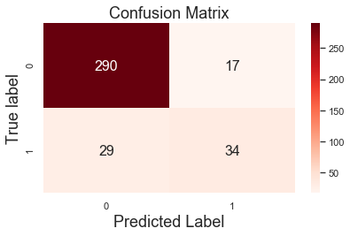

```python
plot_confusion_matrix(y_test, preds)
```

Now, our calibrated model performs much better than the best model from exp1.0, in terms of precision c_1. 67% vs 54%.

### Financial Impact of the Best Model

```python
n_instances = len(X)
p_instances = y.sum() / len(y)
p_targeted = 0.1
n_targeted = int(n_instances*p_targeted)
n_targeted_test = int(len(X_test) * p_targeted)
```

```
              precision    recall  f1-score   support

         0.0       0.00      0.00      0.00         8
         1.0       0.78      1.00      0.88        29

    accuracy                           0.78        37
   macro avg       0.39      0.50      0.44        37
weighted avg       0.61      0.78      0.69        37
```

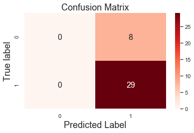

```python
# Create a dataframe of probabilities and actual / predicted outcomes
probs_df = pd.DataFrame(np.hstack([probs, y_test.values.reshape(-1,1), preds.reshape(-1,1)]),
                        columns=['p_no', 'p_yes', 'actual', 'predicted'])


# Sort customers by the probability that they will convert
model_targets = probs_df.sort_values('p_yes', ascending=False)

# Take the top 10%
model_targets = model_targets.head(n_targeted_test)

# Calculate precision matrix
plot_confusion_matrix(model_targets.actual, model_targets.predicted)
```

Picking the top 10% fo our model prediction, the precision went down 6% (~84%) from exp1.0.

```python
# Setup costs and benefits
avg_revenue = params.AVG_REVENUE
avg_cost = params.AVG_COST

# Calculate financial outcomes
random_profit = experiment_1.get_model_profit(X_test, y_test, n_targeted_test, avg_revenue, avg_cost, experiment_1.random_model_predictions)
baseline_profit = experiment_1.get_model_profit(X_test, y_test, n_targeted_test, avg_revenue, avg_cost, experiment_1.baseline_model_predictions)
model_profit = experiment_1.get_model_profit(X_test, y_test, n_targeted_test, avg_revenue, avg_cost, preds=model_targets.actual)

print('Number of customers targeted: {:,}/{:,}'.format(len(model_targets), len(X_test)))
print('Conversion rate of model policy: {:.2f}%'.format(model_targets.actual.sum() / len(y_test)*100.))
print('Expected profit of model policy: ${:,}'.format(model_profit))
print('Lift over random: {:.1f} or ${:,}'.format(model_profit / random_profit, model_profit - random_profit))
print('Lift over baseline: {:.1f} or ${:,}'.format(model_profit / baseline_profit, model_profit - baseline_profit))
```

[output not shown]